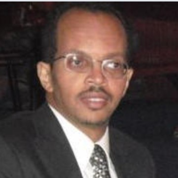

# Mustafa Mohd, MD, MPH

## Bio

An epidemiologist physician with an interest in the application of data science in healthcare quality Improvement, patient safety, and population health. Furthermore, I taught several graduate courses in data analysis and data visualization, in addition to being invited as a guest lecturer in several courses.

## Education

**University of Alabama at Birmingham (UAB)** | Birmingham, AL

Master of Public Health (MPH)

**Royal College of Surgeons in Ireland (RCSI)** | Dublin, Ireland

Clinical Diploma in Child Health (DCH)

**Jordan University of science and Technology (JUST)** | Irbid, Jordan

Medical Doctor (MD)

## Certifications

**Harvard University** | Online Professional Certification Professional Certification in Data Science – (Based on 9 Courses & Capstone)

**Stanford University** | Online Professional Certification Certification in Artificial Intelligence in Healthcare– (Based on 5 Courses)

**Certification Board for Professionals in Patient Safety (CBPPS)** | Certified Professional in Patient Safety (CPPS)

**American Health Information Management Association (AHIMA)** | Certified Health Data Analyst (CHDA)

**National Association for Healthcare Quality (NAHQ)** | Certified Professional in Healthcare Quality (CPHQ),

## Experience

**Contract based** | Clinical Research/Epidemiology Consultant | 2009 - Present

**School of Public Health, UAB**| Instructor/Clinical Data Analyst| 2005 - 2009